# [3] Community-acquired Pneumonia (CAP): WHO AWaRe QIs analysis against gPPS data

CNPI AMR

Last compiled on Sunday 05 October, 2025

# 📊 Report Overview

This report presents a summary of the AWaRe-based quality indicator analysis based on gPPS inpatient data for Community-Acquired Pneumonia (CAP)

This analytical script implements **WHO AWaRe (Access, Watch, Reserve)** antibiotic use **quality indicators (QIs)** for treating **community-acquired pneumonia (CAP)** in adult inpatients with **community-acquired infections (CAIs)**. It utilises standardised data from the Global PPS (gPPS), specifically extracted from Excel-based outputs received by participating hospitals.

**Community-Acquired Pneumonia** (Based on WHO AWaRe Book)  
▸ **gPPS diagnostic code:** `Pneu`  
▸ **gPPS definition:** Includes pneumonia and other lower respiratory tract infections (LRTIs)

The aim is to assess the use of **empirical antibiotic** for respiratory infections, benchmarked against WHO AWaRe guidance, and to provide structured feedback at both the hospital and ward levels. These insights support **antimicrobial stewardship efforts** by highlighting patterns of suboptimal prescribing and identifying opportunities for targeted quality improvement.

## 🎯 WHO AWaRe QIs for CAP

Within the scope of the gPPS data structure, **TWO** QIs has been identified as compatible for evaluating empirical prescribing for pneumonia in adult CAI cases:

**Case Definition:**

1. **H_RESP_WATCH_ABX**: Proportion of patients presenting with bacterial CAP given **IV/oral Watch antibiotics**.
2. **H_RESP_APPROP_ABX**: Proportion of patients presenting with any CAP given the appropriate IV antibiotics according to the WHO AWaRe Antibiotic.

## 💬 General Notes:

- Analysis includes only **adult patients (≥18 years)** with **CAIs** on **empirical** treatment.
- **IV and oral antibiotic administration** are included. IV was inferred using gPPS `"Route"` code `P` (Parenteral).
- It was assumed that WHO recommendations for CAP align with the gPPS diagnostic code `Pneu`
- **QIs** were mapped and interpreted based on clinical assumptions aligning the WHO AWaRe Book with available gPPS codes.

💡 **Reminder:** Caution is advised when interpreting results from small sample sizes (<10 patients)

# 🔍 Initial Eligible Cases Check

This section assesses whether there are enough eligible cases to support meaningful analysis.

**📅 Survey period:** 01 Feb 2025 to 05 Feb 2025

This script applies **WHO AWaRe Quality Indicators** to adult inpatients who received empirical antibiotics for community-acquired pneumonia (CAP).

- **Diagnostic code:** Pneu
- **Total eligible cases:** 24

**✅ Good to go!** Sufficient eligible cases available to proceed with full evaluation.

# 🧾 Summary of CAP Eligible Patients for QI Assessment

Eligible patients for **WHO AWaRe QI** assessment are defined as **adult inpatients (≥18 years)** who received **empirical antibiotics** for **CAP**.

This section presents both **prescription-level** and **patient-level** summaries to establish how much of the dataset is relevant for QI evaluation. It helps frame the proportion of all prescriptions that are relevant to CAP.

## 👥 Patient-Level Summary

This table reports on unique patients in each eligibility group. It reflects the clinical burden of CAP and the proportion of patients suitable for QI evaluation.

**📊 Summary:**  
Total number of patients on antibiotics: **205**  
Total number of eligible patients on antibiotics: **24**

| Patient Category | Number of Patients | Proportion of All Patients |
| --- | --- | --- |
| Number of adult patients (≥18 years) who received empirical antibiotic treatment for CAI | 132 | 64.4% |
| Number of all patients with a diagnosis of pneumonia on any antibiotics | 28 | 13.7% |
| **Number of eligible patients:** Adult patients (≥18 years) with a diagnosis of CAP who were treated empirically with antibiotics | 24 | 11.7% |

## 📑 Prescription-Level Summary

**📊 Summary:**  
Total number of antibiotic prescriptions: **215**  
Total number of eligible antibiotic prescriptions: **25**

| Prescription Category | Number of Prescriptions | Proportion of All Prescriptions |
| --- | --- | --- |
| Number of empirical antibiotic prescriptions administered to adult patients (≥18 years) for CAI | 140 | 65.1% |
| Number of all antibiotic prescriptions for patients diagnosed with pneumonia | 29 | 13.5% |
| **Number of eligible antibiotic prescriptions:** Antibiotics empirically prescribed for adult patients (≥18 years) with CAP | 25 | 11.6% |

# 📘 WHO AWaRe-QIs Overview

This script evaludates **Two** indicators:

1. **H_RESP_WATCH_ABX**: Proportion of patients presenting with bacterial CAP given *IV/oral Watch antibiotics*.
2. **H_RESP_APPROP_ABX**: Proportion of patients presenting with any CAP given the *appropriate IV antibiotics* according to the WHO AWaRe Antibiotic.

**🔍 WHO AWaRe Book Recommendation**

**Mild to Moderate Cases:**  
• First choice: Amoxicillin 1 g q8h (ORAL)  
• First choice: Phenoxymethylpenicillin 500 mg q6h (ORAL)  
• Second choice: Amoxicillin + Clavulanic acid 875/125 mg q8h (ORAL)  
• Second choice: Doxycycline 100 mg q12h (ORAL)

**Severe Cases:**  
• First choice: Cefotaxime 2 g q8h (IV/IM)  
• First choice: Ceftriaxone 2 g q24h (IV) or 1 g q24h (IM)  
• Second choice: Amoxicillin + Clavulanic acid 1 g/200 mg q8h (IV); Higher dose option: 1 g/200 mg q6h (IV)  
• Consider adding: Clarithromycin 500 mg q12h (ORAL or IV) if CURB-65 ≥2

**📘 WHO AWaRe Notes:**

- For mild to moderate CAP, access group antibiotics are typically recommended and are generally administered orally. For severe cases, treatment typically involves IV antibiotics, and most recommendations fall under the Watch group.
- They may be considered only when clinical severity is high (e.g., CURB-65 score ≥2), or pathogen coverage necessitates escalation

# 📌 Indicator 1 - IV/Oral Watch Antibiotic Use

This section evaluates one WHO AWaRe indicator:

> **H_RESP_WATCH_ABX:** Proportion of patients with bacterial CAP given *IV/oral Watch antibiotics*

## 📝 Summary of IV/Oral Antibiotic Use for CAP

This section summarises use of IV/Oral antibiotics for patients with CAP across hospital departments

💊 **Denominator:** Number of eligible CAP patients who received any antibiotics (**24** out of 28)

**Summary:**

**🏥 Hospital-Wide** (n = 24 patients)

- 1 **Received a WATCH antibiotic via IV or Oral route**: **75.0%** (18 out of 24)
- 2 **Received a WATCH antibiotic via other route**: **12.5%** (3 out of 24)
- 3 **Received a NON-WATCH antibiotic**: **16.7%** (4 out of 24)

**🏥 Adult Intensive Care Units** (n = 1 patients)

- 1 **Received a WATCH antibiotic via IV or Oral route**: **0.0%** (0 out of 1)
- 2 **Received a WATCH antibiotic via other route**: **0.0%** (0 out of 1)
- 3 **Received a NON-WATCH antibiotic**: **100.0%** (1 out of 1)

**🏥 Adult surgical wards** (n = 8 patients)

- 1 **Received a WATCH antibiotic via IV or Oral route**: **75.0%** (6 out of 8)
- 2 **Received a WATCH antibiotic via other route**: **0.0%** (0 out of 8)
- 3 **Received a NON-WATCH antibiotic**: **25.0%** (2 out of 8)

**🏥 General Medical Ward** (n = 15 patients)

- 1 **Received a WATCH antibiotic via IV or Oral route**: **80.0%** (12 out of 15)
- 2 **Received a WATCH antibiotic via other route**: **20.0%** (3 out of 15)
- 3 **Received a NON-WATCH antibiotic**: **6.7%** (1 out of 15)

**💡 Note:** The proportions are based on the number of unique CAP patients per department for each specific combination of WHO AWaRe antibiotic category and route of administration. A patient contributes to the count for each distinct AWaRe category and route combination they received. Receiving the same combination multiple times does not increase the count for that combination for that patient.

## 📈 Antibiotic Prescription by AWaRe Classification

This visual summarises the proportion of antibiotic prescription for CAP across hospital departments by WHO AWaRe Classification (Access, Watch, Reserve)

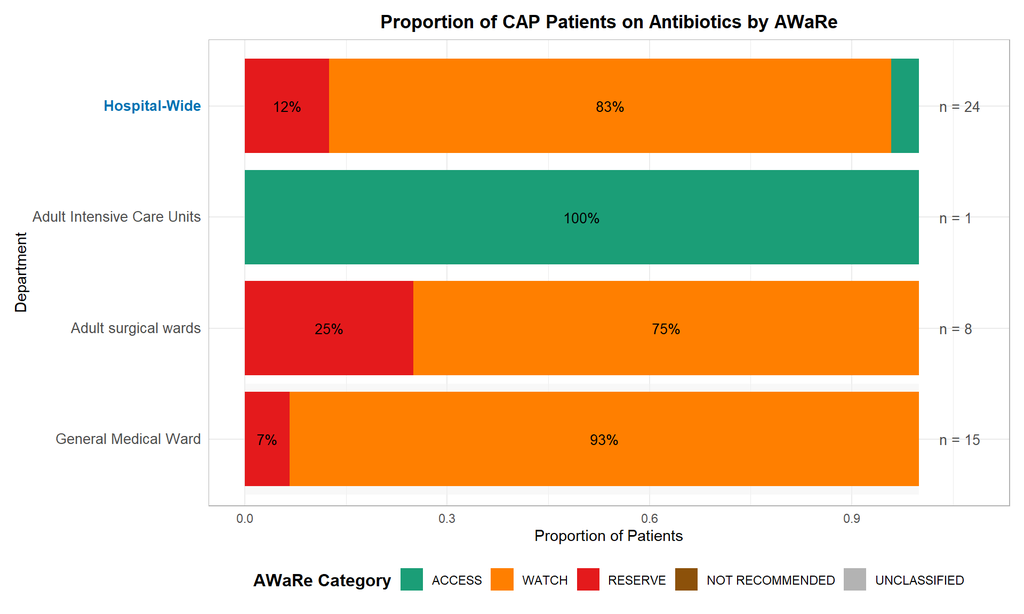

**💡 Note:**

- This count in this visual represents the number of unique patients who were prescribed at least one antibiotic within a specific WHO AWaRe category (Access, Watch, or Reserve) during their encounter. A patient is counted once for each distinct AWaRe category they received an antibiotic from.
- The AWaRe classification divides antibiotics into three categories: Access, Watch, and Reserve. Access antibiotics are first-line treatments with a low risk of resistance, typically recommended for common infections. Watch antibiotics are associated with a higher risk of resistance and require careful monitoring. Reserve antibiotics are reserved for critical cases involving resistant infections, typically used only when other options are ineffective.

## 📈 Antibiotic Prescription by Route of Administration

This visual summarises the proportion of CAP Patients on Watch Antibiotics across hospital departments by Route of Administration

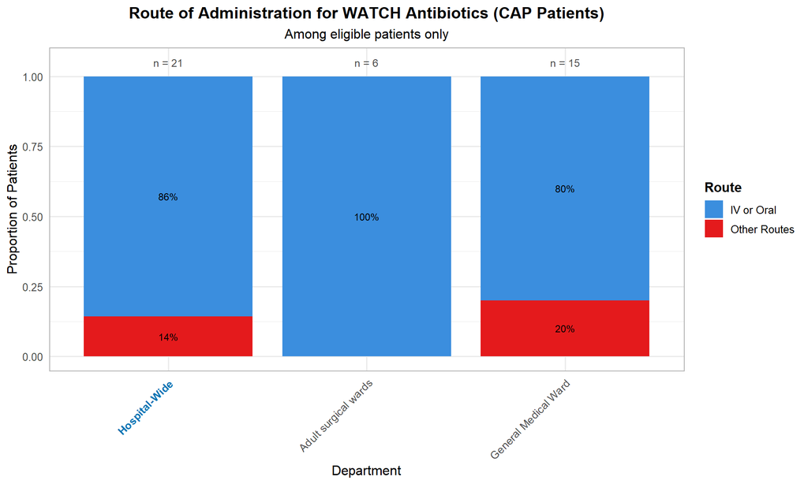

**💡 Note:** This visual shows the proportion of unique CAP patients in each department who received at least one antibiotic from the WHO **Watch** category, considering the route of administration. A patient is counted once for each distinct route through which they received a Watch antibiotic.

# 📌 Indicator 2 – IV Antibiotic Choice & Dosage Appropriateness

> **H_RESP_APPROP_ABX:** Proportion of patients presenting with any CAP given the appropriate IV antibiotics according to the WHO AWaRe Antibiotic Book.

## 📈 Antibiotic Choice Appropriateness for CAP

This section assesses whether adult inpatients with **CAP** were prescribed the appropriate empirical IV/ ORAL antibiotics based on the WHO AWaRe Antibiotic Book.

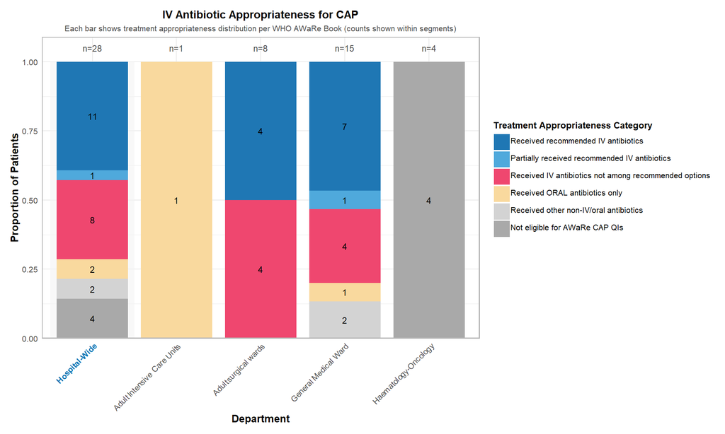

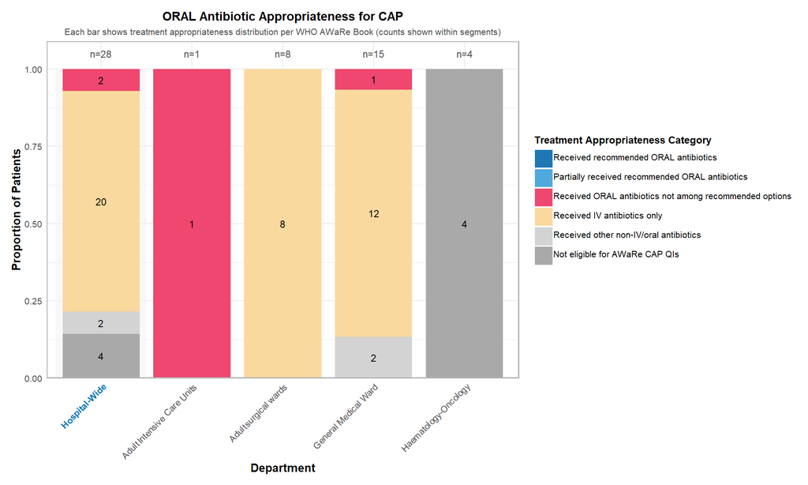

**💡 Note:**

- Because gPPS data do not include clinical severity for CAP cases, we used the route of antibiotic administration as a proxy: the prescription of oral antibiotics was interpreted as treatment for mild or moderate CAP, while the prescription of IV antibiotics was taken to indicate severe CAP. This assumption aligns with WHO AWaRe Book recommendations, which advise oral antibiotics for mild/moderate cases and parenteral antibiotics for severe cases.
- Cases in which oral clarithromycin was added to a WHO AWaRe-recommended IV regimen (Cefotaxime, Ceftriaxone, or Amoxicillin–Clavulanic acid) were also classified as receiving **recommended IV antibiotics**, as clarithromycin is part of the recommended combination for severe CAP (IF CURB-65 ≥2) when the primary antibiotic is given intravenously.

## 📈 Antibiotic Choice Appropriateness by AWaRe Classification

This visual summarises the proportion of IV/ORAL antibiotic choice appropriateness for CAP across hospital departments by WHO AWaRe Classification (Access, Watch, Reserve).

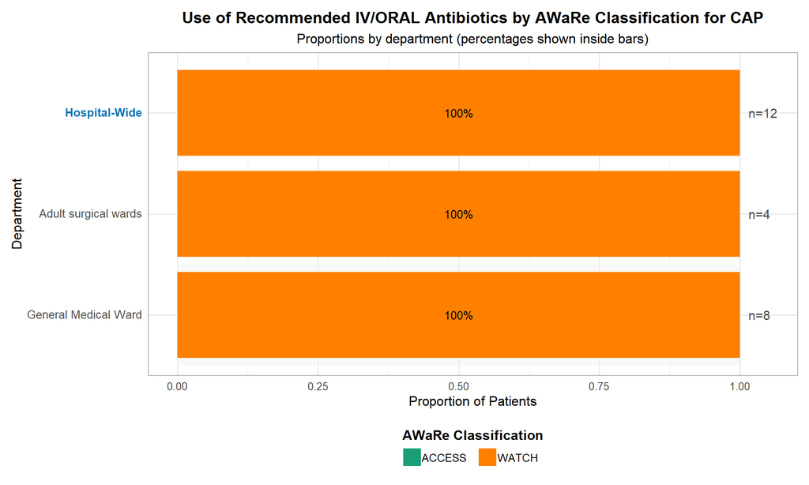

**💡 Note:** The AWaRe classification divides antibiotics into three categories: Access, Watch, and Reserve. Access antibiotics are first-line treatments with a low risk of resistance, typically recommended for common infections. Watch antibiotics are associated with a higher risk of resistance and require careful monitoring. Reserve antibiotics are reserved for critical cases involving resistant infections, typically used only when other options are ineffective .

## 📈 Antibiotic Choice Appropriateness by line of treatment

This visual summarises the proportion of antibiotic choice appropriateness for CAP across hospital departments by line of treatment (First choice, Second choice)

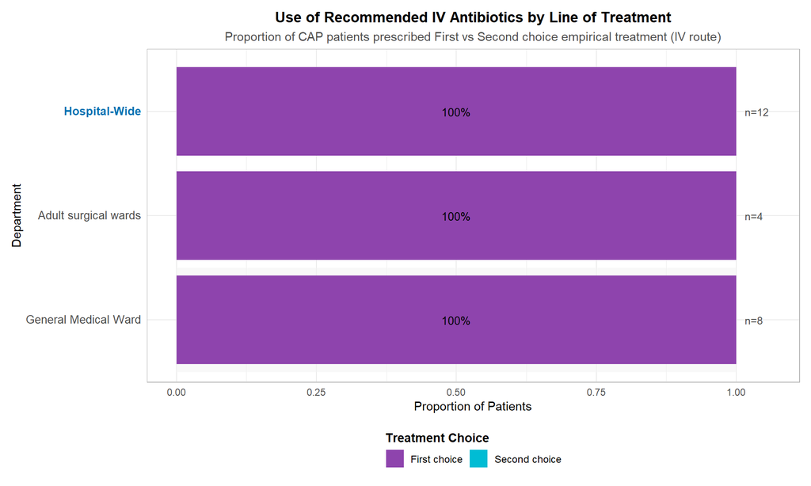

[figure not shown]

**💡 Note:** Patients who received IV/ORAL Clarithromycin alone were not included in this analysis, as it serves as adjunct therapy for CAP (IF CURB-65 ≥2) and does not independently define the treatment line for severe CAP according to the WHO AWaRe Book.

## 📝 Summary of Antibiotic Choice Appropriateness for CAP

### 📋 IV Antibiotic Choice Appropriateness for CAP

This section summarises the proportion of IV antibiotic **choice appropriateness** for CAP across hospital departments based on the WHO AWaRe Book.

💊 **Denominator:** Number of eligible CAP patients who received any IV antibiotic (**20** out of **24**)

**Summary:**

**🏥 Hospital-Wide** (n = 20 patients)

- ✅ **Received recommended IV antibiotics** (as per WHO AWaRe Book): **55.0%** (11 out of 20)
- ⚠️ **Partially received recommended IV antibiotics** (as per WHO AWaRe Book): **5.0%** (1 out of 20)
- ❌ **Received IV antibiotics not among recommended options** (as per WHO AWaRe Book): **40.0%** (8 out of 20)

**🏥 Adult surgical wards** (n = 8 patients)

- ✅ **Received recommended IV antibiotics** (as per WHO AWaRe Book): **50.0%** (4 out of 8)
- ⚠️ **Partially received recommended IV antibiotics** (as per WHO AWaRe Book): **0.0%** (0 out of 8)
- ❌ **Received IV antibiotics not among recommended options** (as per WHO AWaRe Book): **50.0%** (4 out of 8)

**🏥 General Medical Ward** (n = 12 patients)

- ✅ **Received recommended IV antibiotics** (as per WHO AWaRe Book): **58.3%** (7 out of 12)
- ⚠️ **Partially received recommended IV antibiotics** (as per WHO AWaRe Book): **8.3%** (1 out of 12)
- ❌ **Received IV antibiotics not among recommended options** (as per WHO AWaRe Book): **33.3%** (4 out of 12)

### 📋 ORAL Antibiotic Choice Appropriateness for CAP

This section summarises the proportion of ORAL antibiotic **choice appropriateness** for CAP across hospital departments based on the WHO AWaRe Book.

💊 **Denominator:** Number of eligible CAP patients who received any ORAL antibiotic (**2** out of **24**)

**Summary:**

**🏥 Hospital-Wide** (n = 2 patients)

- ✅ **Received recommended ORAL antibiotics** (as per WHO AWaRe Book): **0.0%** (0 out of 2)
- ⚠️ **Partially received recommended ORAL antibiotics** (as per WHO AWaRe Book): **0.0%** (0 out of 2)
- ❌ **Received ORAL antibiotics not among recommended options** (as per WHO AWaRe Book): **100.0%** (2 out of 2)

**🏥 Adult Intensive Care Units** (n = 1 patients)

- ✅ **Received recommended ORAL antibiotics** (as per WHO AWaRe Book): **0.0%** (0 out of 1)
- ⚠️ **Partially received recommended ORAL antibiotics** (as per WHO AWaRe Book): **0.0%** (0 out of 1)
- ❌ **Received ORAL antibiotics not among recommended options** (as per WHO AWaRe Book): **100.0%** (1 out of 1)

**🏥 General Medical Ward** (n = 1 patients)

- ✅ **Received recommended ORAL antibiotics** (as per WHO AWaRe Book): **0.0%** (0 out of 1)
- ⚠️ **Partially received recommended ORAL antibiotics** (as per WHO AWaRe Book): **0.0%** (0 out of 1)
- ❌ **Received ORAL antibiotics not among recommended options** (as per WHO AWaRe Book): **100.0%** (1 out of 1)

**💡 Note:** The partially recommended category refers to cases where patients received only part of the recommended antibiotic regimen. This includes cases where recommended antibiotics were combined with others outside the intended combination.

## 📈 Antibiotic Choice & Dosage Appropriateness for CAP

This visual summarises the proportion of IV/ ORAL antibiotic choice & dosage appropriateness for CAP across hospital departments based on the WHO AWaRe Book.

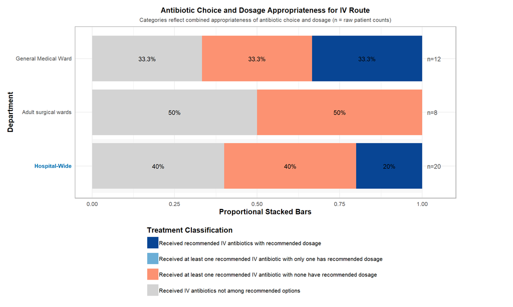

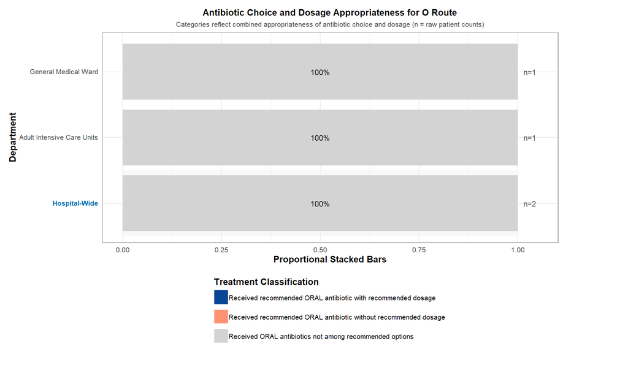

**💡 Notes:**

- **Received recommended IV antibiotics with recommended dosage** indicates that the full recommended treatment regimen (whether monotherapy or dual therapy) was given, with all dosages aligned with WHO AWaRe Book guidance.
- **Received at least one recommended IV antibiotic with one has recommended dosage** refers to cases where only part of the recommended dual therapy was given, and only one antibiotic was at the recommended dosage.
- **Received at least one recommended IV antibiotic with none have recommended dosage** includes cases who received either the full recommended regimen with no recommended dosages, or only part of it (e.g., one agent from a dual therapy) with none of the dosages aligned with WHO AWaRe Book guidance.

**💡 Notes:**

- Cases where oral clarithromycin was given alongside a recommended IV antibiotic (Cefotaxime, Ceftriaxone, or Amoxicillin–Clavulanic acid) were considered appropriate IV treatment. Because clarithromycin is part of the recommended combination for severe CAP (CURB-65 ≥2), these cases were excluded from the oral antibiotic appropriateness assessment
- The combined total of patients in the oral and IV antibiotic choice/dosage appropriateness assessment summaries may exceed the overall number of patients, as some were prescribed both oral and IV treatments — so they are included in both summaries.

## 📝 Summary of Antibiotic Choice & Dosage Appropriateness for CAP

### 📋 IV Antibiotic Choice Appropriateness for CAP

This section evaluates the **appropriateness of IV antibiotic drug dosage** for patients with CAP, in line with the WHO AWaRe Book guidance.

💊 **Denominator:** Number of eligible CAP patients who received recommended (*or partially recommended*) IV antibiotic choice based on WHO AWaRe Book (**12** out of 24)

**Summary:**

**🏥 Hospital-Wide** (n = 12 patients)

- ✅ **Received recommended IV antibiotics with recommended dosage** (as per WHO AWaRe Book): **33.3%** (4 out of 12)
- ⚠️ **Received at least one recommended IV antibiotic with only one has recommended dosage** (as per WHO AWaRe Book): **0.0%** (0 out of 12)
- ❌ **Received at least one recommended IV antibiotic with none have recommended dosage** (as per WHO AWaRe Book): **66.7%** (8 out of 12)

**🏥 Adult surgical wards** (n = 4 patients)

- ✅ **Received recommended IV antibiotics with recommended dosage** (as per WHO AWaRe Book): **0.0%** (0 out of 4)
- ⚠️ **Received at least one recommended IV antibiotic with only one has recommended dosage** (as per WHO AWaRe Book): **0.0%** (0 out of 4)
- ❌ **Received at least one recommended IV antibiotic with none have recommended dosage** (as per WHO AWaRe Book): **100.0%** (4 out of 4)

**🏥 General Medical Ward** (n = 8 patients)

- ✅ **Received recommended IV antibiotics with recommended dosage** (as per WHO AWaRe Book): **50.0%** (4 out of 8)
- ⚠️ **Received at least one recommended IV antibiotic with only one has recommended dosage** (as per WHO AWaRe Book): **0.0%** (0 out of 8)
- ❌ **Received at least one recommended IV antibiotic with none have recommended dosage** (as per WHO AWaRe Book): **50.0%** (4 out of 8)

### 📋 ORAL Antibiotic Choice Appropriateness for CAP

This section evaluates the **appropriateness of ORAL antibiotic drug dosage** for patients with CAP, in line with the WHO AWaRe Book guidance.

⚠️ **No summary available** — there are currently no eligible CAP patients for assessing ORAL antibiotic dosage appropriateness.  
*This may indicate that no patients met the inclusion criteria, or no patients received recommended ORAL antibiotics during the reporting period.*